# Final project

You Valérie

April 4th, 2022

# INTRODUCTION

This dataset has been downloaded from Kaggle:  
[<https://www.kaggle.com/datasets/leonardopena/top50spotify2019>](https://www.kaggle.com/datasets/leonardopena/top50spotify2019)

It contains the Top 50 most listened songs in the world by Spotify in 2019. This dataset has 13 variables about the songs.

From the vintage gramaphones through mix tapes through radio, our listening medium has now reached online music-streaming platforms. Spotify, Apple music, Google play etc are some of the most popular of these.

Spotify is the most popular subscription audio streaming service in the world, with 248 million users including 113 million subscribers in 79 markets. Today, Spotify is the company that generates the most revenue for the music industry.

# Presentation and description of the problem

Music has always been an indispensable aspect of our daily life. Over the past decades, our sources of listening to them have also evolved over time.

It would be interesting to understand what are the important factors that make a song more successful than others. Through this analysis, we will try to identify the popular songs or artists and evaluate if there are some correlations between characteristics of the songs, the popularity and the genre.

We also want to show the results of this analysis in an intuitive way by visualizing outcome using ggplot2 in R. This analysis will be conducted thanks to the contents that we have learnt from Programming for BA but also from the other courses we had before (Correlation Matrix, Boxplot, Scatterplox).

# I. Presentation of the data

## 1.1. Importing the dataset (+description)

We have information about artist name, track title and genre. The rest columns contain numerical values about:

- **BPM** - the tempo of the song,
- **Energy**- the energy of a song - the higher the value, the more energtic song is,
- **Danceability** - the higher the value, the easier it is to dance to this song,
- **Loudness** - the higher the value, the louder the song,
- **Liveness** - the higher the value, the more likely the song is a live recording,
- **Valence** - the higher the value, the more positive mood for the song,
- **Length** - the duration of the song,
- **Acousticness** - the higher the value the more acoustic the song is,
- **Speechiness** - the higher the value the more spoken word the song contains,
- **Popularity** - the higher the value the more popular the song is.

```r
library(readr)
spotify_ds <- read_csv("FINAL PROJECT/top50.csv")

knitr::kable((spotify_ds))%>%
  kable_styling(font_size = 8, bootstrap_options = "striped", full_width = TRUE)
```

| …1 | Track.Name | Artist.Name | Genre | Beats.Per.Minute | Energy | Danceability | Loudness..dB.. | Liveness | Valence. | Length. | Acousticness.. | Speechiness. | Popularity |
| --- | --- | --- | --- | --- | --- | --- | --- | --- | --- | --- | --- | --- | --- |
| 1 | Se<f1>orita | Shawn Mendes | canadian pop | 117 | 55 | 76 | -6 | 8 | 75 | 191 | 4 | 3 | 79 |
| 2 | China | Anuel AA | reggaeton flow | 105 | 81 | 79 | -4 | 8 | 61 | 302 | 8 | 9 | 92 |
| 3 | boyfriend (with Social House) | Ariana Grande | dance pop | 190 | 80 | 40 | -4 | 16 | 70 | 186 | 12 | 46 | 85 |
| 4 | Beautiful People (feat. Khalid) | Ed Sheeran | pop | 93 | 65 | 64 | -8 | 8 | 55 | 198 | 12 | 19 | 86 |
| 5 | Goodbyes (Feat. Young Thug) | Post Malone | dfw rap | 150 | 65 | 58 | -4 | 11 | 18 | 175 | 45 | 7 | 94 |
| 6 | I Don’t Care (with Justin Bieber) | Ed Sheeran | pop | 102 | 68 | 80 | -5 | 9 | 84 | 220 | 9 | 4 | 84 |
| 7 | Ransom | Lil Tecca | trap music | 180 | 64 | 75 | -6 | 7 | 23 | 131 | 2 | 29 | 92 |
| 8 | How Do You Sleep? | Sam Smith | pop | 111 | 68 | 48 | -5 | 8 | 35 | 202 | 15 | 9 | 90 |
| 9 | Old Town Road - Remix | Lil Nas X | country rap | 136 | 62 | 88 | -6 | 11 | 64 | 157 | 5 | 10 | 87 |
| 10 | bad guy | Billie Eilish | electropop | 135 | 43 | 70 | -11 | 10 | 56 | 194 | 33 | 38 | 95 |
| 11 | Callaita | Bad Bunny | reggaeton | 176 | 62 | 61 | -5 | 24 | 24 | 251 | 60 | 31 | 93 |
| 12 | Loco Contigo (feat. J. Balvin & Tyga) | DJ Snake | dance pop | 96 | 71 | 82 | -4 | 15 | 38 | 185 | 28 | 7 | 86 |
| 13 | Someone You Loved | Lewis Capaldi | pop | 110 | 41 | 50 | -6 | 11 | 45 | 182 | 75 | 3 | 88 |
| 14 | Otro Trago - Remix | Sech | panamanian pop | 176 | 79 | 73 | -2 | 6 | 76 | 288 | 7 | 20 | 87 |
| 15 | Money In The Grave (Drake ft. Rick Ross) | Drake | canadian hip hop | 101 | 50 | 83 | -4 | 12 | 10 | 205 | 10 | 5 | 92 |
| 16 | No Guidance (feat. Drake) | Chris Brown | dance pop | 93 | 45 | 70 | -7 | 16 | 14 | 261 | 12 | 15 | 82 |
| 17 | LA CANCI<d3>N | J Balvin | latin | 176 | 65 | 75 | -6 | 11 | 43 | 243 | 15 | 32 | 90 |
| 18 | Sunflower - Spider-Man: Into the Spider-Verse | Post Malone | dfw rap | 90 | 48 | 76 | -6 | 7 | 91 | 158 | 56 | 5 | 91 |
| 19 | Lalala | Y2K | canadian hip hop | 130 | 39 | 84 | -8 | 14 | 50 | 161 | 18 | 8 | 88 |
| 20 | Truth Hurts | Lizzo | escape room | 158 | 62 | 72 | -3 | 12 | 41 | 173 | 11 | 11 | 91 |
| 21 | Piece Of Your Heart | MEDUZA | pop house | 124 | 74 | 68 | -7 | 7 | 63 | 153 | 4 | 3 | 91 |
| 22 | Panini | Lil Nas X | country rap | 154 | 59 | 70 | -6 | 12 | 48 | 115 | 34 | 8 | 91 |
| 23 | No Me Conoce - Remix | Jhay Cortez | reggaeton flow | 92 | 79 | 81 | -4 | 9 | 58 | 309 | 14 | 7 | 83 |
| 24 | Soltera - Remix | Lunay | latin | 92 | 78 | 80 | -4 | 44 | 80 | 266 | 36 | 4 | 91 |
| 25 | bad guy (with Justin Bieber) | Billie Eilish | electropop | 135 | 45 | 67 | -11 | 12 | 68 | 195 | 25 | 30 | 89 |
| 26 | If I Can’t Have You | Shawn Mendes | canadian pop | 124 | 82 | 69 | -4 | 13 | 87 | 191 | 49 | 6 | 70 |
| 27 | Dance Monkey | Tones and I | australian pop | 98 | 59 | 82 | -6 | 18 | 54 | 210 | 69 | 10 | 83 |
| 28 | It’s You | Ali Gatie | canadian hip hop | 96 | 46 | 73 | -7 | 19 | 40 | 213 | 37 | 3 | 89 |
| 29 | Con Calma | Daddy Yankee | latin | 94 | 86 | 74 | -3 | 6 | 66 | 193 | 11 | 6 | 91 |
| 30 | QUE PRETENDES | J Balvin | latin | 93 | 79 | 64 | -4 | 36 | 94 | 222 | 3 | 25 | 89 |
| 31 | Takeaway | The Chainsmokers | edm | 85 | 51 | 29 | -8 | 10 | 36 | 210 | 12 | 4 | 84 |
| 32 | 7 rings | Ariana Grande | dance pop | 140 | 32 | 78 | -11 | 9 | 33 | 179 | 59 | 33 | 89 |
| 33 | 0.958333333333333 | Maluma | reggaeton | 96 | 71 | 78 | -5 | 9 | 68 | 176 | 22 | 28 | 89 |
| 34 | The London (feat. J. Cole & Travis Scott) | Young Thug | atl hip hop | 98 | 59 | 80 | -7 | 13 | 18 | 200 | 2 | 15 | 89 |
| 35 | Never Really Over | Katy Perry | dance pop | 100 | 88 | 77 | -5 | 32 | 39 | 224 | 19 | 6 | 89 |
| 36 | Summer Days (feat. Macklemore & Patrick Stump of Fall Out Boy) | Martin Garrix | big room | 114 | 72 | 66 | -7 | 14 | 32 | 164 | 18 | 6 | 89 |
| 37 | Otro Trago | Sech | panamanian pop | 176 | 70 | 75 | -5 | 11 | 62 | 226 | 14 | 34 | 91 |
| 38 | Antisocial (with Travis Scott) | Ed Sheeran | pop | 152 | 82 | 72 | -5 | 36 | 91 | 162 | 13 | 5 | 87 |
| 39 | Sucker | Jonas Brothers | boy band | 138 | 73 | 84 | -5 | 11 | 95 | 181 | 4 | 6 | 80 |
| 40 | fuck, i’m lonely (with Anne-Marie) - from <93>13 Reasons Why: Season 3<94> | Lauv | dance pop | 95 | 56 | 81 | -6 | 6 | 68 | 199 | 48 | 7 | 78 |
| 41 | Higher Love | Kygo | edm | 104 | 68 | 69 | -7 | 10 | 40 | 228 | 2 | 3 | 88 |
| 42 | You Need To Calm Down | Taylor Swift | dance pop | 85 | 68 | 77 | -6 | 7 | 73 | 171 | 1 | 5 | 90 |
| 43 | Shallow | Lady Gaga | dance pop | 96 | 39 | 57 | -6 | 23 | 32 | 216 | 37 | 3 | 87 |
| 44 | Talk | Khalid | pop | 136 | 40 | 90 | -9 | 6 | 35 | 198 | 5 | 13 | 84 |
| 45 | Con Altura | ROSAL<cd>A | r&b en espanol | 98 | 69 | 88 | -4 | 5 | 75 | 162 | 39 | 12 | 88 |
| 46 | One Thing Right | Marshmello | brostep | 88 | 62 | 66 | -2 | 58 | 44 | 182 | 7 | 5 | 88 |
| 47 | Te Robar<e9> | Nicky Jam | latin | 176 | 75 | 67 | -4 | 8 | 80 | 202 | 24 | 6 | 88 |
| 48 | Happier | Marshmello | brostep | 100 | 79 | 69 | -3 | 17 | 67 | 214 | 19 | 5 | 88 |
| 49 | Call You Mine | The Chainsmokers | edm | 104 | 70 | 59 | -6 | 41 | 50 | 218 | 23 | 3 | 88 |
| 50 | Cross Me (feat. Chance the Rapper & PnB Rock) | Ed Sheeran | pop | 95 | 79 | 75 | -6 | 7 | 61 | 206 | 21 | 12 | 82 |

## 1.2. Exploratory data analysis

- Examination

```r
head(spotify_ds)
```

```
## # A tibble: 6 × 14
##    ...1 Track.Name      Artist.Name  Genre  Beats.Per.Minute Energy Danceability
##   <dbl> <chr>           <chr>        <chr>             <dbl>  <dbl>        <dbl>
## 1     1 "Se\xf1orita"   Shawn Mendes canad…              117     55           76
## 2     2 "China"         Anuel AA     regga…              105     81           79
## 3     3 "boyfriend (wi… Ariana Gran… dance…              190     80           40
## 4     4 "Beautiful Peo… Ed Sheeran   pop                  93     65           64
## 5     5 "Goodbyes (Fea… Post Malone  dfw r…              150     65           58
## 6     6 "I Don't Care … Ed Sheeran   pop                 102     68           80
## # … with 7 more variables: Loudness..dB.. <dbl>, Liveness <dbl>,
## #   Valence. <dbl>, Length. <dbl>, Acousticness.. <dbl>, Speechiness. <dbl>,
## #   Popularity <dbl>
```

The number of variables (columns) is 14 and there are 50 observations (rows).

```r
ncol(spotify_ds)
```

```
## [1] 14
```

```r
nrow(spotify_ds)
```

```
## [1] 50
```

- Checking for missing values

```r
missingvalues <- colSums(is.na(spotify_ds))
missingvalues
```

```
##             ...1       Track.Name      Artist.Name            Genre
##                0                0                0                0
## Beats.Per.Minute           Energy     Danceability   Loudness..dB..
##                0                0                0                0
##         Liveness         Valence.          Length.   Acousticness..
##                0                0                0                0
##     Speechiness.       Popularity
##                0                0
```

- List of genres

```r
table(spotify_ds$Genre)
```

```
##
##      atl hip hop   australian pop         big room         boy band
##                1                1                1                1
##          brostep canadian hip hop     canadian pop      country rap
##                2                3                2                2
##        dance pop          dfw rap              edm       electropop
##                8                2                3                2
##      escape room            latin   panamanian pop              pop
##                1                5                2                7
##        pop house   r&b en espanol        reggaeton   reggaeton flow
##                1                1                2                2
##       trap music
##                1
```

- List of artists

```r
table(spotify_ds$Artist.Name)
```

```
##
##        Ali Gatie         Anuel AA    Ariana Grande        Bad Bunny
##                1                1                2                1
##    Billie Eilish      Chris Brown     Daddy Yankee         DJ Snake
##                2                1                1                1
##            Drake       Ed Sheeran         J Balvin      Jhay Cortez
##                1                4                2                1
##   Jonas Brothers       Katy Perry           Khalid             Kygo
##                1                1                1                1
##        Lady Gaga             Lauv    Lewis Capaldi        Lil Nas X
##                1                1                1                2
##        Lil Tecca            Lizzo            Lunay           Maluma
##                1                1                1                1
##       Marshmello    Martin Garrix           MEDUZA        Nicky Jam
##                2                1                1                1
##      Post Malone       ROSAL\xcdA        Sam Smith             Sech
##                2                1                1                2
##     Shawn Mendes     Taylor Swift The Chainsmokers      Tones and I
##                2                1                2                1
##              Y2K       Young Thug
##                1                1
```

# II. Data cleaning

## 2.1. Removing unnecessary column

Here, I want to remove the first column as I find it unnecessary

```r
spotify_ds = subset(spotify_ds, select = -c(...1))

knitr::kable(head(spotify_ds))%>%
  kable_styling(font_size = 8, bootstrap_options = "striped", full_width = TRUE)
```

| Track.Name | Artist.Name | Genre | Beats.Per.Minute | Energy | Danceability | Loudness..dB.. | Liveness | Valence. | Length. | Acousticness.. | Speechiness. | Popularity |
| --- | --- | --- | --- | --- | --- | --- | --- | --- | --- | --- | --- | --- |
| Se<f1>orita | Shawn Mendes | canadian pop | 117 | 55 | 76 | -6 | 8 | 75 | 191 | 4 | 3 | 79 |
| China | Anuel AA | reggaeton flow | 105 | 81 | 79 | -4 | 8 | 61 | 302 | 8 | 9 | 92 |
| boyfriend (with Social House) | Ariana Grande | dance pop | 190 | 80 | 40 | -4 | 16 | 70 | 186 | 12 | 46 | 85 |
| Beautiful People (feat. Khalid) | Ed Sheeran | pop | 93 | 65 | 64 | -8 | 8 | 55 | 198 | 12 | 19 | 86 |
| Goodbyes (Feat. Young Thug) | Post Malone | dfw rap | 150 | 65 | 58 | -4 | 11 | 18 | 175 | 45 | 7 | 94 |
| I Don’t Care (with Justin Bieber) | Ed Sheeran | pop | 102 | 68 | 80 | -5 | 9 | 84 | 220 | 9 | 4 | 84 |

## 2.2. Renaming confusing sub-genres

```r
spotify_ds$Genre <- gsub("dance pop", "pop", spotify_ds$Genre)
spotify_ds$Genre <- gsub("canadian hip hop", "rap/hip hop", spotify_ds$Genre)
spotify_ds$Genre <- gsub("panamanian pop", "pop", spotify_ds$Genre)
spotify_ds$Genre <- gsub("dfw rap", "rap/hip hop", spotify_ds$Genre)
spotify_ds$Genre <- gsub("country rap", "rap/hip hop", spotify_ds$Genre)
spotify_ds$Genre <- gsub("trap music", "rap/hip hop", spotify_ds$Genre)
spotify_ds$Genre <- gsub("boy band", "pop", spotify_ds$Genre)
spotify_ds$Genre <- gsub("australian pop", "pop", spotify_ds$Genre)
spotify_ds$Genre <- gsub("reggaeton flow", "reggaeton", spotify_ds$Genre)
spotify_ds$Genre <- gsub("pophouse", "house", spotify_ds$Genre)
spotify_ds$Genre <- gsub("canadian pop", "pop", spotify_ds$Genre)
spotify_ds$Genre <- gsub("reggaeton", "reggaeton", spotify_ds$Genre)
spotify_ds$Genre <- gsub("electropop", "pop", spotify_ds$Genre)
spotify_ds$Genre <- gsub("electropop", "pop", spotify_ds$Genre)
spotify_ds$Genre <- gsub("atl hip hop", "rap/hip hop", spotify_ds$Genre)
spotify_ds$Genre <- gsub("escape room", "r&b", spotify_ds$Genre)
spotify_ds$Genre <- gsub("r&b en espanol", "r&b", spotify_ds$Genre)
spotify_ds$Genre <- gsub("big room", "house", spotify_ds$Genre)
```

- **Cleaned dataframe**

```r
knitr::kable((spotify_ds))%>%
  kable_styling(font_size = 8, bootstrap_options = "striped", full_width = TRUE)
```

| Track.Name | Artist.Name | Genre | Beats.Per.Minute | Energy | Danceability | Loudness..dB.. | Liveness | Valence. | Length. | Acousticness.. | Speechiness. | Popularity |
| --- | --- | --- | --- | --- | --- | --- | --- | --- | --- | --- | --- | --- |
| Se<f1>orita | Shawn Mendes | pop | 117 | 55 | 76 | -6 | 8 | 75 | 191 | 4 | 3 | 79 |
| China | Anuel AA | reggaeton | 105 | 81 | 79 | -4 | 8 | 61 | 302 | 8 | 9 | 92 |
| boyfriend (with Social House) | Ariana Grande | pop | 190 | 80 | 40 | -4 | 16 | 70 | 186 | 12 | 46 | 85 |
| Beautiful People (feat. Khalid) | Ed Sheeran | pop | 93 | 65 | 64 | -8 | 8 | 55 | 198 | 12 | 19 | 86 |
| Goodbyes (Feat. Young Thug) | Post Malone | rap/hip hop | 150 | 65 | 58 | -4 | 11 | 18 | 175 | 45 | 7 | 94 |
| I Don’t Care (with Justin Bieber) | Ed Sheeran | pop | 102 | 68 | 80 | -5 | 9 | 84 | 220 | 9 | 4 | 84 |
| Ransom | Lil Tecca | rap/hip hop | 180 | 64 | 75 | -6 | 7 | 23 | 131 | 2 | 29 | 92 |
| How Do You Sleep? | Sam Smith | pop | 111 | 68 | 48 | -5 | 8 | 35 | 202 | 15 | 9 | 90 |
| Old Town Road - Remix | Lil Nas X | rap/hip hop | 136 | 62 | 88 | -6 | 11 | 64 | 157 | 5 | 10 | 87 |
| bad guy | Billie Eilish | pop | 135 | 43 | 70 | -11 | 10 | 56 | 194 | 33 | 38 | 95 |
| Callaita | Bad Bunny | reggaeton | 176 | 62 | 61 | -5 | 24 | 24 | 251 | 60 | 31 | 93 |
| Loco Contigo (feat. J. Balvin & Tyga) | DJ Snake | pop | 96 | 71 | 82 | -4 | 15 | 38 | 185 | 28 | 7 | 86 |
| Someone You Loved | Lewis Capaldi | pop | 110 | 41 | 50 | -6 | 11 | 45 | 182 | 75 | 3 | 88 |
| Otro Trago - Remix | Sech | pop | 176 | 79 | 73 | -2 | 6 | 76 | 288 | 7 | 20 | 87 |
| Money In The Grave (Drake ft. Rick Ross) | Drake | rap/hip hop | 101 | 50 | 83 | -4 | 12 | 10 | 205 | 10 | 5 | 92 |
| No Guidance (feat. Drake) | Chris Brown | pop | 93 | 45 | 70 | -7 | 16 | 14 | 261 | 12 | 15 | 82 |
| LA CANCI<d3>N | J Balvin | latin | 176 | 65 | 75 | -6 | 11 | 43 | 243 | 15 | 32 | 90 |
| Sunflower - Spider-Man: Into the Spider-Verse | Post Malone | rap/hip hop | 90 | 48 | 76 | -6 | 7 | 91 | 158 | 56 | 5 | 91 |
| Lalala | Y2K | rap/hip hop | 130 | 39 | 84 | -8 | 14 | 50 | 161 | 18 | 8 | 88 |
| Truth Hurts | Lizzo | r&b | 158 | 62 | 72 | -3 | 12 | 41 | 173 | 11 | 11 | 91 |
| Piece Of Your Heart | MEDUZA | pop house | 124 | 74 | 68 | -7 | 7 | 63 | 153 | 4 | 3 | 91 |
| Panini | Lil Nas X | rap/hip hop | 154 | 59 | 70 | -6 | 12 | 48 | 115 | 34 | 8 | 91 |
| No Me Conoce - Remix | Jhay Cortez | reggaeton | 92 | 79 | 81 | -4 | 9 | 58 | 309 | 14 | 7 | 83 |
| Soltera - Remix | Lunay | latin | 92 | 78 | 80 | -4 | 44 | 80 | 266 | 36 | 4 | 91 |
| bad guy (with Justin Bieber) | Billie Eilish | pop | 135 | 45 | 67 | -11 | 12 | 68 | 195 | 25 | 30 | 89 |
| If I Can’t Have You | Shawn Mendes | pop | 124 | 82 | 69 | -4 | 13 | 87 | 191 | 49 | 6 | 70 |
| Dance Monkey | Tones and I | pop | 98 | 59 | 82 | -6 | 18 | 54 | 210 | 69 | 10 | 83 |
| It’s You | Ali Gatie | rap/hip hop | 96 | 46 | 73 | -7 | 19 | 40 | 213 | 37 | 3 | 89 |
| Con Calma | Daddy Yankee | latin | 94 | 86 | 74 | -3 | 6 | 66 | 193 | 11 | 6 | 91 |
| QUE PRETENDES | J Balvin | latin | 93 | 79 | 64 | -4 | 36 | 94 | 222 | 3 | 25 | 89 |
| Takeaway | The Chainsmokers | edm | 85 | 51 | 29 | -8 | 10 | 36 | 210 | 12 | 4 | 84 |
| 7 rings | Ariana Grande | pop | 140 | 32 | 78 | -11 | 9 | 33 | 179 | 59 | 33 | 89 |
| 0.958333333333333 | Maluma | reggaeton | 96 | 71 | 78 | -5 | 9 | 68 | 176 | 22 | 28 | 89 |
| The London (feat. J. Cole & Travis Scott) | Young Thug | rap/hip hop | 98 | 59 | 80 | -7 | 13 | 18 | 200 | 2 | 15 | 89 |
| Never Really Over | Katy Perry | pop | 100 | 88 | 77 | -5 | 32 | 39 | 224 | 19 | 6 | 89 |
| Summer Days (feat. Macklemore & Patrick Stump of Fall Out Boy) | Martin Garrix | house | 114 | 72 | 66 | -7 | 14 | 32 | 164 | 18 | 6 | 89 |
| Otro Trago | Sech | pop | 176 | 70 | 75 | -5 | 11 | 62 | 226 | 14 | 34 | 91 |
| Antisocial (with Travis Scott) | Ed Sheeran | pop | 152 | 82 | 72 | -5 | 36 | 91 | 162 | 13 | 5 | 87 |
| Sucker | Jonas Brothers | pop | 138 | 73 | 84 | -5 | 11 | 95 | 181 | 4 | 6 | 80 |
| fuck, i’m lonely (with Anne-Marie) - from <93>13 Reasons Why: Season 3<94> | Lauv | pop | 95 | 56 | 81 | -6 | 6 | 68 | 199 | 48 | 7 | 78 |
| Higher Love | Kygo | edm | 104 | 68 | 69 | -7 | 10 | 40 | 228 | 2 | 3 | 88 |
| You Need To Calm Down | Taylor Swift | pop | 85 | 68 | 77 | -6 | 7 | 73 | 171 | 1 | 5 | 90 |
| Shallow | Lady Gaga | pop | 96 | 39 | 57 | -6 | 23 | 32 | 216 | 37 | 3 | 87 |
| Talk | Khalid | pop | 136 | 40 | 90 | -9 | 6 | 35 | 198 | 5 | 13 | 84 |
| Con Altura | ROSAL<cd>A | r&b | 98 | 69 | 88 | -4 | 5 | 75 | 162 | 39 | 12 | 88 |
| One Thing Right | Marshmello | brostep | 88 | 62 | 66 | -2 | 58 | 44 | 182 | 7 | 5 | 88 |
| Te Robar<e9> | Nicky Jam | latin | 176 | 75 | 67 | -4 | 8 | 80 | 202 | 24 | 6 | 88 |
| Happier | Marshmello | brostep | 100 | 79 | 69 | -3 | 17 | 67 | 214 | 19 | 5 | 88 |
| Call You Mine | The Chainsmokers | edm | 104 | 70 | 59 | -6 | 41 | 50 | 218 | 23 | 3 | 88 |
| Cross Me (feat. Chance the Rapper & PnB Rock) | Ed Sheeran | pop | 95 | 79 | 75 | -6 | 7 | 61 | 206 | 21 | 12 | 82 |

# III. Visualization of the data

## 3.1. The number of songs per artist

According to the analysis, Ed Sheeran is the artist that has the highest amount of songs in 2019’s Top 50.

```r
spotify_ds %>%
  select(Artist.Name) %>%
  group_by(Artist.Name) %>%
  summarise(n()) %>%
  view()
```

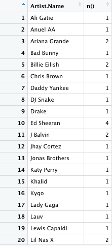

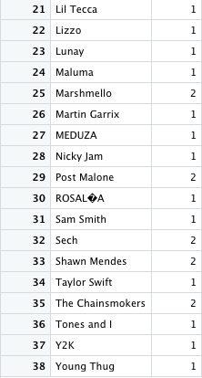

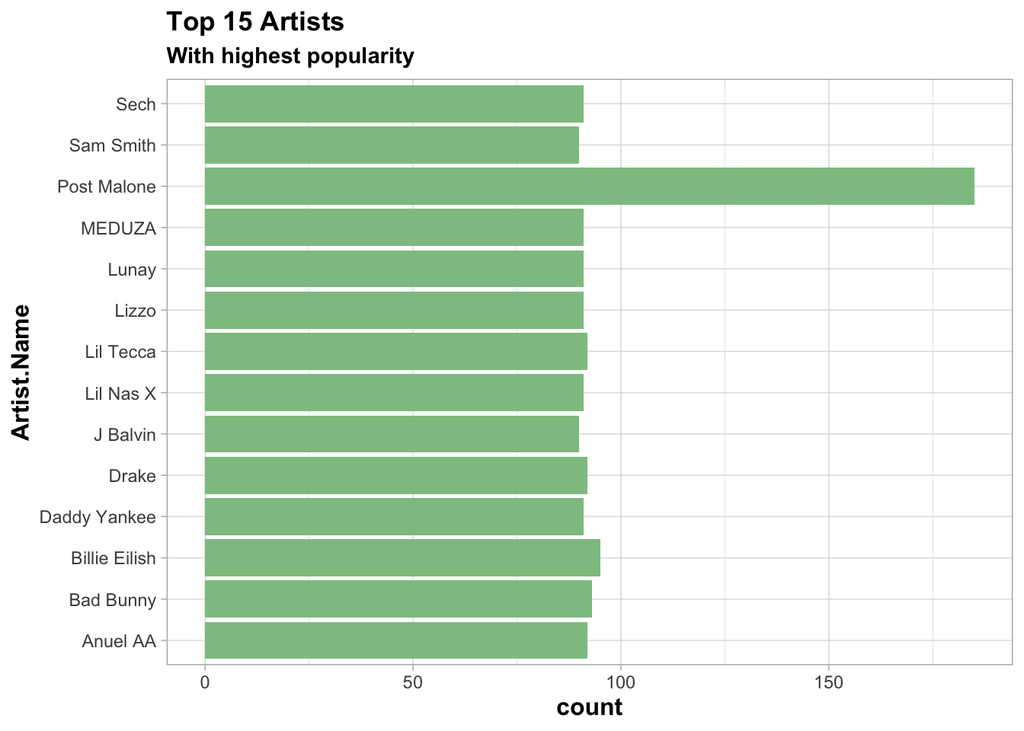

```r
spotify_pop <- spotify_ds %>%
  arrange(desc(Popularity)) %>%
  head(15)

Artist_pop_plot= ggplot(spotify_pop) +
  aes(x = Artist.Name, weight = Popularity) +
  geom_bar(fill = "#90C290") +
  labs(title = "Top 15 Artists", subtitle = "With highest popularity") +
  coord_flip() +
  theme_light() +
  theme(
    plot.title = element_text(face = "bold"),
    plot.subtitle = element_text(face = "bold"),
    axis.title.y = element_text(size = 12L,
    face = "bold"),
    axis.title.x = element_text(size = 12L,
    face = "bold")
  )
Artist_pop_plot
```

## 3.3. Top Genre according to Popularity

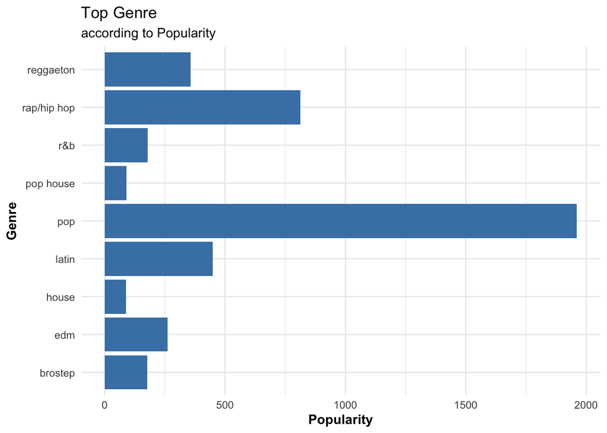

```r
top_genre = spotify_ds %>%
 filter(!(Artist.Name %in% "ROSAL\xcdA")) %>%
 ggplot() +
  aes(x = Genre, weight = Popularity) +
  geom_bar(fill = "#4682B4") +
  labs(
    x = "Genre",
    y = "Popularity",
    title = "Top Genre",
    subtitle = "according to Popularity"
  ) +
  coord_flip() +
  theme_minimal() +
  theme(
    axis.title.y = element_text(face = "bold"),
    axis.title.x = element_text(face = "bold")
  )

top_genre
```

## 3.4. Correlation matrix to define the genre

- **Number, correlation matrix**

In this plot, correlation coefficients are colored according to their value. Value of correlation coefficients can vary between -1 (strong negative correlation) and 1 (strong positive correlation). 0 indicates that there is no correlation between the variables. Another method of visualization is the association of the blue color for the coefficients close to 1 and red for the coefficients which tend towards -1.

Through this correlation matrix, we can identify the variables (characteristics) that have an influence on the genre.

For example, we can stand that energetic songs are correlated to the loudness of it. The most positive correlations are between Energy and Loudness (0,67), followed by BPM and Speechiness (0,56). The strongest negative correlations are between Energy and Accousticness (-0,34), followed by Loudness and Speechiness (-0,27).

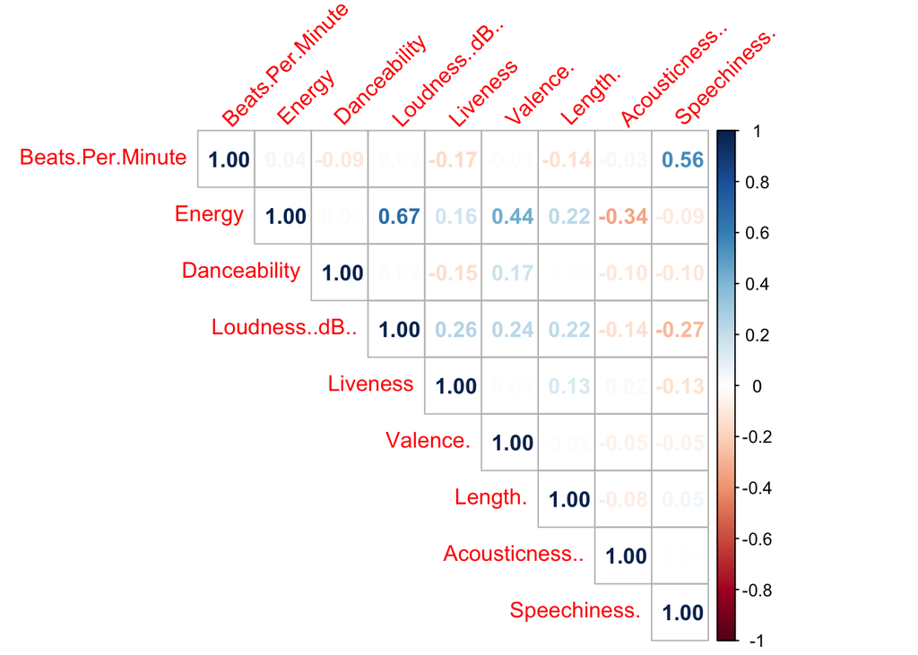

```r
library(corrplot)
spotify_corr <- select(spotify_ds, -c(Track.Name,  Artist.Name ,Genre, Popularity))
mtCor <- cor(spotify_corr)
corrplot(mtCor, method = "number", type = "upper", tl.srt = 45)
```

- **Correlation matrix including Popularity**

This is another alternative of correlation matrix. In this case, I will not remove Popularity in order to evaluate which variable influence on the Popularity of a song.

According to the correlation matrix, we can stand that, thanks to the blue color and direction of the ellipses, the BPM, Speechiness and Liveness are positively correlated to the popularity.  
In contrast, Valence is negatively correlated to the popularity as the ellipse is likely orange.

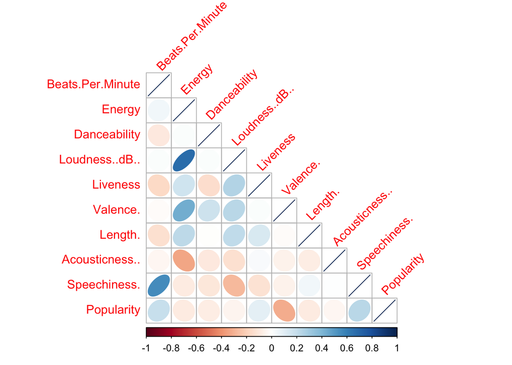

```r
library(corrplot)
spotify_corr <- select(spotify_ds, -c(Track.Name,  Artist.Name ,Genre))
mtCor <- cor(spotify_corr)
corrplot(mtCor, method = "ellipse", type = "lower", tl.srt = 45)
```

## 3.5. Scatterplot

From the above correlation matrix, we can see that there is a strong positive correlation between Energy and Loudness. It means that songs the loud of a song determine if it is energetic or not. We can also provide a scatter plot to visualize the correlation between the characteristics.

The scatterplot confirms that there is a positive correlation Energy and Loudness.

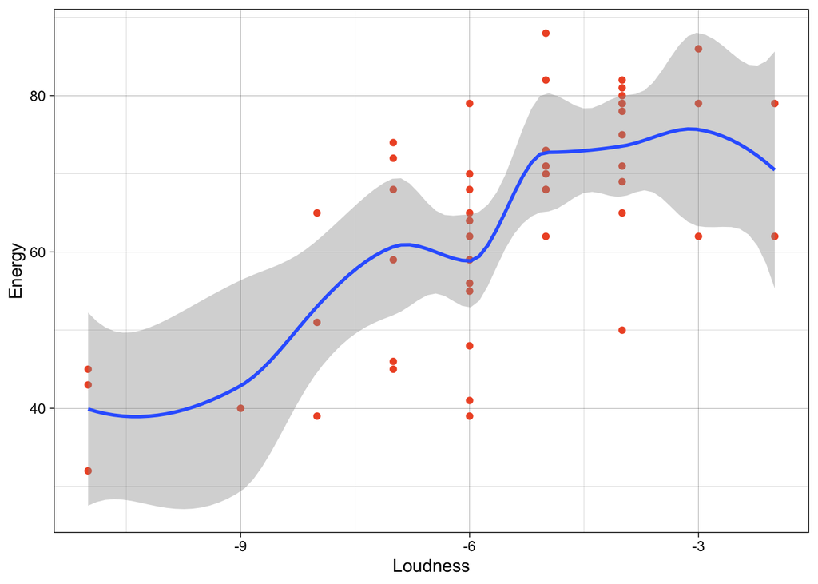

```r
spotify_sp_eL =
  spotify_ds %>%
 filter(!(Artist.Name %in% "ROSAL\xcdA")) %>%
 ggplot() +
  aes(x = Loudness..dB.., y = Energy) +
  geom_point(shape = "circle", size = 1.5, colour = "#EF562D") +
  geom_smooth(span = 0.48) +
  labs(x = "Loudness") +
  theme_linedraw()

spotify_sp_eL
```

We can do the same to confirm our initial observation regarding the correlation between Energy and Acousticness and it is negative.

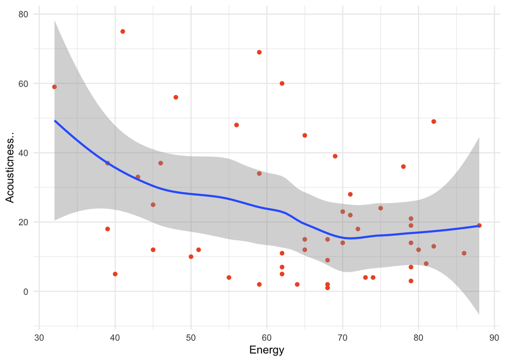

```r
spotify_sp_eA =
  spotify_ds %>%
 filter(!(Artist.Name %in% "ROSAL\xcdA")) %>%
 ggplot() +
  aes(x = Energy, y = Acousticness..) +
  geom_point(shape = "circle", size = 1.5, colour = "#EF562D") +
  geom_smooth(span = 0.75) +
  theme_minimal()

spotify_sp_eA
```

## 3.6. Boxplot

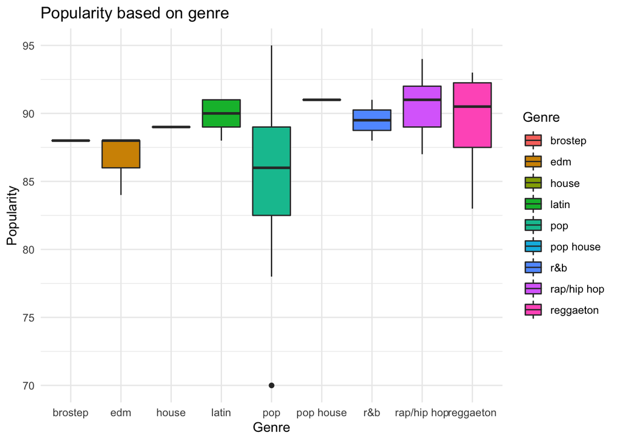

```r
mygraph_bp = spotify_ds %>%
 filter(!(Artist.Name %in% "ROSAL\xcdA")) %>%
 ggplot() +
  aes(x = Genre, y = Popularity, fill = Genre) +
  geom_boxplot() +
  scale_fill_hue(direction = 1) +
   labs(
    x = "Genre",
    y = "Popularity",
    title = "Popularity based on genre") +
  theme_minimal()

mygraph_bp
```

- Average energy per genre

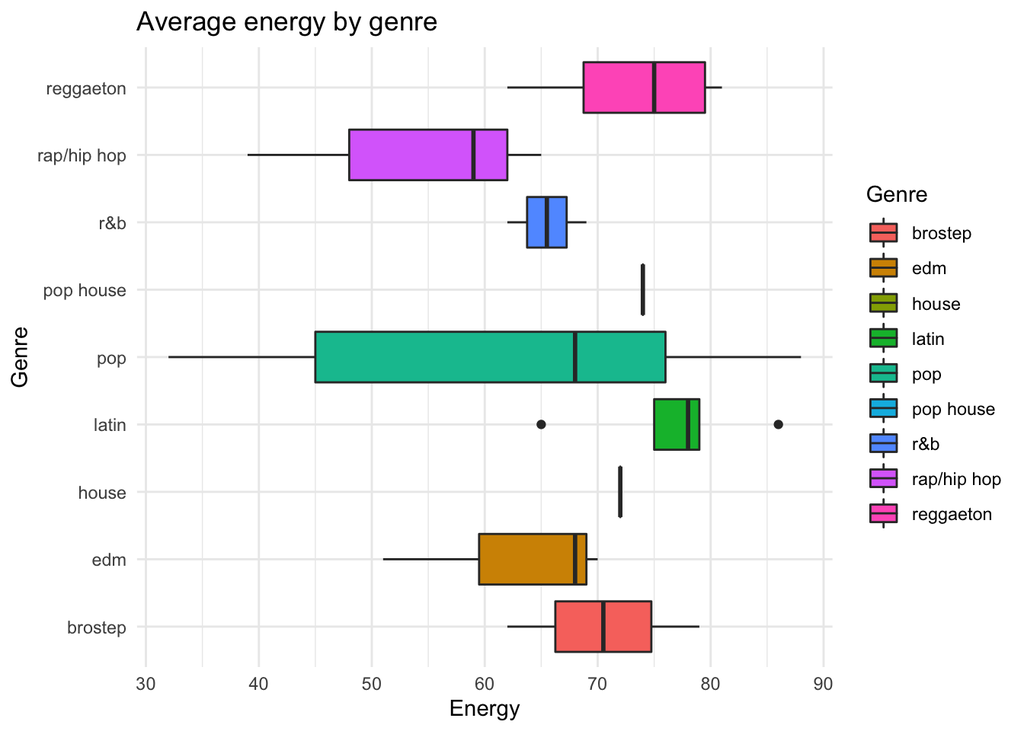

```r
mygraph_AEG =
  spotify_ds %>%
 filter(!(Artist.Name %in% "ROSAL\xcdA")) %>%
 ggplot() +
  aes(x = Energy, y = Genre, fill = Genre) +
  geom_boxplot() +
  scale_fill_hue(direction = 1) +
  labs(title = "Average energy by genre") +
  theme_minimal()
mygraph_AEG
```

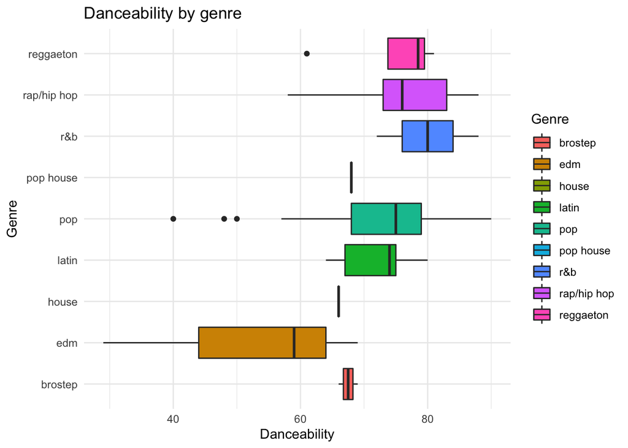

```r
mygraph_AVG =
  spotify_ds %>%
 filter(!(Artist.Name %in% "ROSAL\xcdA")) %>%
 ggplot() +
  aes(x = Danceability, y = Genre, fill = Genre) +
  geom_boxplot() +
  scale_fill_hue(direction = 1) +
  labs(title = "Danceability by genre") +
  theme_minimal()
mygraph_AVG
```

# Interpretation and conclusion

However, the observations may not be really relevant and representative because it only contains 50 observations. The correlations may change with more songs.

# References

[<https://www.kaggle.com/datasets/leonardopena/top50spotify2019>](https://www.kaggle.com/datasets/leonardopena/top50spotify2019)

https://towardsdatascience.com/k-means-clustering-and-pca-to-categorize-music-by-similar-audio-features-df09c93e8b64